# CellPlotManual

Sven E. Templer, Robert Sehlke

2018-11-22

# Description

**CellPlot** is a [GNU R](http://r-project.org) package with plot methods for the integrated visualisation of functional term enrichment and expression data. It can be used to display commonly used gene ontology (GO) term enrichment analysis from differential expression of genes (DEG) studies.

The development platform of this software is hosted on [github](https://github.com/dieterich-lab/CellPlot). In case of any questions, consider using the issues system.

# Usage

## Load package and data

After installing the package (see Installation section), load it in a running **R** session. Example data can be accessed with the `data()` function.

```r
library(CellPlot)
data("leukemiasGO")
```

## Plot methods

Example to create a subset of the `leukemiasGO` data set tables:

```r
x <- subset(leukemiasGO$CLL, pvalCutOff <= 0.05 & Significant > 20)
x <- x[order(-x$LogEnrich),]
```

### Cell Plot

The function `cell.plot` plots a horizontal barchart of strictly positive values in x. For each entry, a vector of additional values needs to be provided in a list. The additional values are plotted as cells subdividing the length of the corresponding bar. A typical usage scenario is plotting the enrichment of Gene Ontology terms, with individual cells reflecting the differential regulation of the constituent genes.

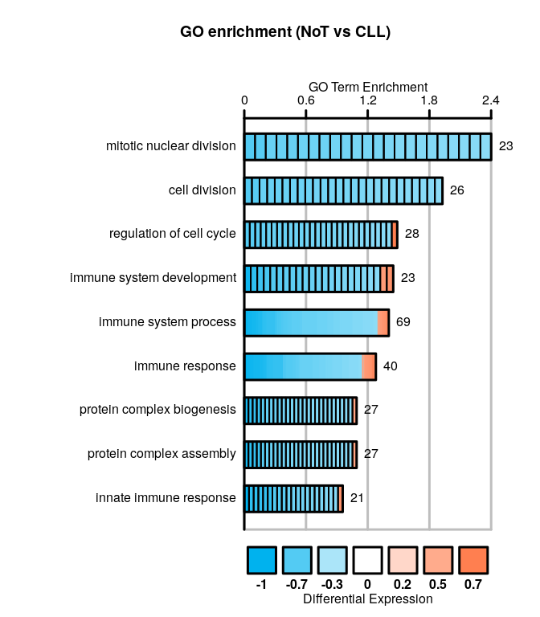

```r
cell.plot(x = setNames(x$LogEnrich, x$Term),
          cells = x$log2FoldChange,
          main ="GO enrichment (NoT vs CLL)",
          x.mar = c(.4, 0),
          key.n = 7,
          y.mar = c(.1, 0),
          cex = 1.6,
          cell.outer = 3,
          bar.scale = .7,
          space = .2)
```

### Sym Plot

The function `sym.plot` plots a split barchart, showing the proportions of two mutually exclusive sets in relation to a set containing them both. E.g., Gene Ontology terms, showing the proportions of differentially down-regulated and up-regulated annotated genes from a perturbation experiment. The color of the central column elements maps to the value provided in x (e.g. GO term enrichment). Associated genes may be provided as a list of vectors of expression values, same as for cell.plot(), or as separate vectors x.up and x.down, providing the numbers of up- and down-regulated genes in the same order as x.

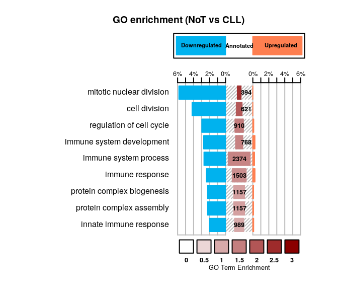

```r
sym.plot(x = setNames(x$LogEnrich, x$Term),
         cells = x$log2FoldChange,
         x.annotated = x$Annotated,
         main = "GO enrichment (NoT vs CLL)",
         x.mar = c(.47, 0),
         key.n = 7,
         cex = 1.6,
         axis.cex = .8,
         group.cex = .7)
```

### Arc Plot

An `arc.plot` represents enrichment bargraphs, showing abundance of positive and negative values (e.g. log2 fold change of gene expression comparisons). Units (e.g. gene names) are clustered and intersections are indicated by an arc.

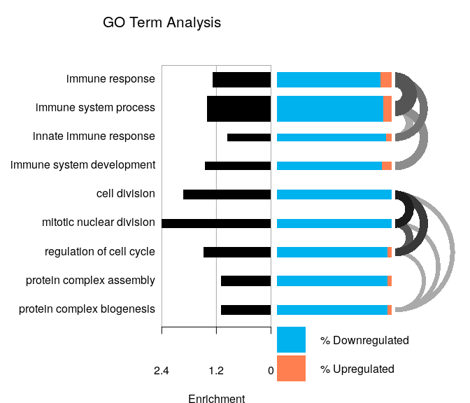

```r
x$up <- lapply(Map(setNames, x$log2FoldChange, x$GenesSignificant), function (i) { i[i>0] })
x$dwn <- lapply(Map(setNames, x$log2FoldChange, x$GenesSignificant), function (i) { i[i<0] })
arc.plot(x = setNames(x$LogEnrich, x$Term),
         up.list = x$up,
         down.list = x$dwn,
         x.mar = c(.9, .5))
```

## Go Histogram

A bargraph showing positive and negative value abundances per category. Supply a list of data.frames and compare each table, performing a one sided t-test on the absolute `logfc.term` values.

Data is prepared as follows:

```r
y <- lapply(leukemiasGO, function (x) {
  x$Upregulated <- sapply(x$log2FoldChange, function (z) sum(z>0))
  x$Downregulated <- sapply(x$log2FoldChange, function (z) sum(z<0))
  x
})
yterms <- unique(unlist(lapply(y, function(x){
  x <- subset(x, pvalCutOff <= 0.05)
  x <- x[order(x$LogEnrich),]
  head(x, 9)$GO.ID
})))
```

An the plot generated:

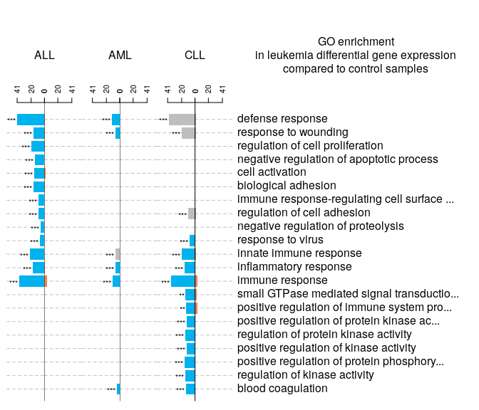

```r
par(mar = c(0,.5,2.5,8))
go.histogram(y, go.alpha.term = "pvalCutOff", gene.alpha.term = "padj",
             min.genes = 5, max.genes = 1e10, go.selection = yterms, show.ttest = T,
             main = "GO enrichment\nin leukemia differential gene expression\ncompared to control samples",
             axis.cex = 1, lab.cex = 1.5, main.cex = 1.5)
```

## Visual parameters

Both functions provide a range of parameters to tweak the visual appearance of the plots.

- **Font sizes** of the various elements can be adjusted using the `cex` parameters.
- **Internal margins** are adjusted through `x.mar` and `y.mar`. Used in particular to accomodate the label text to the left-hand side.
- **Absolute scaling** can be achieved through the `bar.scale` parameter, which acts as a multiplier for a predetermined average bar height. This is meant to be used in conjunction with a graphics device of constant size, to ensure visual consistency among multiple plots that vary in the number of terms displayed.
- **Data ranges** for all output may be fixed:
  - `elem.bounds` Require the cardinality of a term or significant subset to be in a specific range, e.g. `c(10,100)` – between 10 and 100 genes.
  - `x.bound` Upper limit of the value displayed on the x-axis. For `sym.plot` this is must be a value between 0 and 100. The lower limit is always 0.
  - `cell.bounds` (only `cell.plot`) Sets the colour scale for cell data to a fixed range. If the plot contains values outside of that range, an indicator is added to the colour legend. This is particularly useful in the event of a few extreme outliers.
  - `mid.bounds` (only `sym.plot`) Similar to `cell.bounds`, this sets the colour range of the central column cells.
  - `sym` (only `cell.plot`), when set to `TRUE`, makes the scale of cell values symmetrical.
- **Colour schemes** may be controlled through character vectors provided to the following parameters. Internally, the R native function `ColorRampPalette()` is used.
  - `cell.col` (only `cell.plot`) Specify three valid colour names for cell data visualisation (lower extreme, mid point, upper extreme).
  - `mid.col` (only `sym.plot`) Specify two valid colour names to define the range of the central column cell colours.
- **Colour keys** can be adjusted in their resolution (number of boxes) using the `key.n` parameter.
- **Gridlines** may be hidden via the `gridlines` parameter.

# Workflows

Gene ontology term enrichment in differential gene expression data can be performed using the [Bioconductor/topGO](http://www.bioconductor.org/packages/release/bioc/html/topGO.html) package.

## Dataset `leukemiasGO`

This section provides code and comments on the workflow to perform differential expression of genes analysis and the gene ontology term enrichment of from the results applied to the `leukemiasEset` dataset from the [Bioconductor/leukemiasEset](http://www.bioconductor.org/packages/release/data/experiment/html/leukemiasEset.html) package. GO annotation was performed with the [Bioconductor/annotate](http://www.bioconductor.org/packages/release/bioc/html/annotate.html)

```r
# CRAN
library(parallel)
library(dplyr)
library(stringr)
# Bioconductor
library(BiocParallel)
library(DESeq2)
library(topGO)
library(annotate)
library(leukemiasEset)

data(leukemiasEset)

# M <- select(hu6800.db, featureNames(leukemiasEset), c("ENSEMBL","GO"), keytype = "ENSEMBL")
# M <- subset(M, ONTOLOGY == "BP", c("ENSEMBL","GO"))
# M <- M[!duplicated(M),]
# M <- dlply(M, "ENSEMBL", function (x) unique(x$GO))

# M <- as.character(unique(unlist(select(org.Hs.eg.db,featureNames(leukemiasEset),"ENSEMBL",keytype = "ENSEMBL"))))

A <- as(leukemiasEset,"data.frame")
A <- subset(A, LeukemiaType %in% c("NoL","ALL", "AML", "CLL"))
As <- subset(A, select = "LeukemiaType")
As$LeukemiaType <- relevel(factor(as.character(As$LeukemiaType)), "NoL")
A <- subset(A, select = grepl("^ENS", colnames(A)))
A <- sapply(A, as.integer)
A <- t(A)

DEG <- DESeqDataSetFromMatrix(countData = A, colData = As, design = ~ LeukemiaType)
DEG <- DESeq(DEG, fitType = "mean", parallel = T, BPPARAM = MulticoreParam(20))

n <- levels(As$LeukemiaType)[-1]
leukemiasGO <- lapply(setNames(n, n), function (n) {
  x <- results(DEG, c("LeukemiaType", n, "NoL"), "LeukemiaType", alpha = .05)
  x <- as.data.frame(x)
  x$padj[is.na(x$padj)] <- 1
  g <- new("topGOdata", ontology = "BP", description = 'Leukemia',
           allGenes = setNames(x$padj, rownames(x)),
           mapping = "org.Hs.eg.db",
           geneSelectionFun = function (allScore) { allScore <= 0.05 },
           annotationFun = annFUN.org, ID = "Ensembl")
  t <- new("elimCount", testStatistic = GOFisherTest, name = "Fisher test") # test definition
  s <- getSigGroups(g, t) # run F-test
  r <- GenTable(g, pvalCutOff = s, topNodes = length(g@graph@nodes)) # return data.frame
  r$pvalCutOff <- as.numeric(str_replace_all(r$pvalCutOff, "[^0-9e\\-\\.]*", ""))
  r$LogEnrich <- log2(r$Significant / r$Expected)
  ga <- genesInTerm(g) # GenesAnnotated | list of genes per go-terms
  ga <- ga[r$GO.ID] # eliminate missing terms
  names(ga) <- NULL
  r$GenesAnnotated <- ga
  xs <- x[,c("padj", "log2FoldChange")] # significant stats subset
  xs <- subset(xs, padj < 0.05)
  r$GenesSignificant <- lapply(r$GenesAnnotated, intersect, rownames(xs)) # extract genes
  ei.rows <- mclapply(r$GenesSignificant, function (y) {
    if (length(y)) as.list(xs[y,,drop=FALSE])
    else as.list(rep(NA_real_, length(xs)))
  }, mc.cores = 10)
  ei <- mclapply(names(xs), function(z) {
    lapply(ei.rows, "[[", z)
  }, mc.cores = 10)
  ei <- structure(ei, names = names(xs), row.names = seq(nrow(r)), class = "data.frame")
  row.names(ei) <- NULL
  r <- data.frame(r, ei, stringsAsFactors = FALSE, check.names = FALSE)
  return(r)
})

# lapply(GO, function(x) {list(all(r$Annotated == sapply(r$GenesAnnotated, length)),
#                              all(r$Significant == sapply(r$GenesSignificant, length)))})

leukemiasGO <- lapply(leukemiasGO, function(x) subset(x, pvalCutOff < 0.1))
save(leukemiasGO, file = "data/leukemiasGO.rdata")
```

# Installation

## CellPlot

Install the latest version from the repository on github.com/dieterich-lab/CellPlot. With the `devtools` package, it is an easy task:

```r
install_github('dieterich-lab/CellPlot', build_vignettes = TRUE)
```

## Dependencies

To install the packages from Bioconducter, use the following steps:

```r
# load bioconductor functions
source("https://bioconductor.org/biocLite.R")

# install packages
biocLite("BiocParallel")
biocLite("annotate")
biocLite("DESeq2")
biocLite("topGO")
biocLite("leukemiasEset")
```

Dependencies from CRAN can be installed via:

```r
# install packages
install.packages(c("stringr","dplyr","knitr","rmarkdown","devtools"))
```